# Predictive Modeling for Recidivism

Xiaxin Tang and Regy Septiang

April 24, 2024

## 1 Introduction

In response to the challenges of recidivism—the likelihood of a convicted criminal to reoffend—the state of Georgia has embarked on an initiative to implement data-driven predictive models in their criminal justice system. Drawing on the lessons from investigations like the one in Fort Lauderdale, Florida, which exposed significant racial biases in risk assessments[^1], this project utilizes a comprehensive dataset provided by the National Institute of Justice to develop a fair and accurate model for predicting recidivism within three years post-release[^2].

The balance between sensitivity (the ability to correctly identify true positives) and specificity (the ability to correctly identify true negatives) is crucial in this context. Prioritizing sensitivity may lead to fewer individuals who might reoffend being overlooked, thus potentially enhancing public safety; however, this could also result in more false positives—individuals incorrectly labeled as likely to reoffend—thereby possibly subjecting them to undue scrutiny or sanctions. On the other hand, emphasizing specificity minimizes the risk of false positives but increases the likelihood of missing those who do reoffend, posing a direct risk to community safety. Our goal is to develop a model that judiciously balances these aspects, reducing bias and improving outcomes across diverse demographic groups.

## 2 Data Set Up

In this section, we prepare the dataset for the analysis by cleaning and transforming the data to a format suitable for building a predictive model. Our primary focus is the outcome variable, Recidivism_Within_3years, which indicates whether an individual reoffended within three years post-release. This binary variable is crucial for our analysis, and we recode it from “true/false” to “1/0” for compatibility with logistic regression techniques used later in the modeling process.

The dataset, sourced from the National Institute of Justice[^3], encompasses a wide range of variables that potentially influence recidivism. For our initial model setup, we select a subset of these variables, focusing on demographics, risk assessments, and program attendances which are indicative of the individual’s engagement in rehabilitation programs. The selected variables are:

ID and basic demographics like Gender and Race. The initial Supervision Risk Score which provides a quantified assessment of the individual’s risk level at the start of supervision. Education Level and Dependents, as socioeconomic factors often correlate with recidivism. The primary offense leading to the current prison term, providing context on the nature of criminal behavior. The total number of program attendances, reflecting participation in correctional intervention programs, which is a significant factor in rehabilitation. During data cleaning, we convert Program_Attendances and Dependents from their original formats to numeric, enabling quantitative analysis. Missing values in Program_Attendances and Dependents are imputed with logical placeholder values (10 and 3, respectively), based on median values or other domain knowledge assumptions, to maintain the integrity of our dataset for analysis.

The final step in our data setup involves removing any remaining incomplete records to ensure the robustness of the predictive modeling process. This clean, transformed dataset forms the foundation for our subsequent exploratory data analysis and model building efforts.

## 3 Exploratory Data Analysis

### 3.1 Continuous Variables

Based on the plot results, several observations regarding the continuous variables and their relationship with recidivism are seen as follows:

-The distribution for individuals who did not reoffend (labeled as “No Recidivism”) peaks sharply towards the higher percentage of days employed, indicating that a larger proportion of these individuals were employed for most of the time after their release. This peak suggests a strong association between higher employment rates and lower recidivism.

Overall, the density plot reinforces the idea that employment status is potentially a strong predictor of recidivism, with higher employment rates being indicative of a lower likelihood of reoffending. This relationship underscores the importance of employment support as part of reentry programs for formerly incarcerated individuals.

These observations provide preliminary insights into the factors associated with recidivism and highlight the importance of considering both individual and combined effects of variables when building predictive models. The Supervision Risk Score shows promise as a differentiator, while program attendance and employment rates may serve as supplementary indicators in the context of a multifactorial analysis.

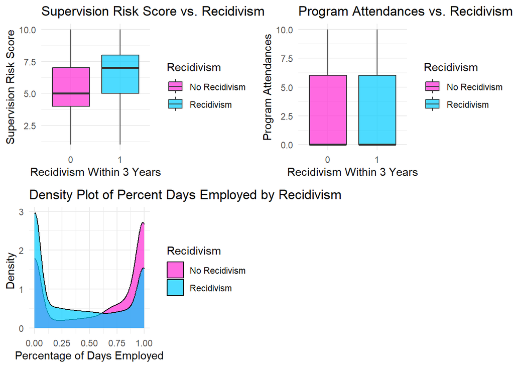

```r
# Continuous variables
# Box plot: Supervision Risk Score vs. Recidivism
supervision_boxplot <- ggplot(df, aes(x = factor(Recidivism_Within_3years), y = Supervision_Risk_Score_First, fill = factor(Recidivism_Within_3years))) +
  geom_boxplot(alpha = 0.7) +
  labs(title = "Supervision Risk Score vs. Recidivism",
       x = "Recidivism Within 3 Years",
       y = "Supervision Risk Score",
       fill = "Recidivism") +
  scale_fill_manual(values = palette_2_colors,
                    labels = c("No Recidivism", "Recidivism")) +
  theme_minimal()

# Box plot: Program Attendances vs. Recidivism
program_attendances_boxplot <- ggplot(df, aes(x = factor(Recidivism_Within_3years), y = Program_Attendances, fill = factor(Recidivism_Within_3years))) +
  geom_boxplot(alpha = 0.7) +
  labs(title = "Program Attendances vs. Recidivism",
       x = "Recidivism Within 3 Years",
       y = "Program Attendances",
       fill = "Recidivism") +
  scale_fill_manual(values = palette_2_colors,
                    labels = c("No Recidivism", "Recidivism")) +
  theme_minimal()

# Bar plot: Percent Days Employed vs. Recidivism
# percent_days_employed_barplot <- ggplot(df, aes(x = Percent_Days_Employed, fill = factor(Recidivism_Within_3years))) +
#   geom_bar(position = "fill", alpha = 0.7) +
#   labs(title = "Percent Days Employed Distribution by Recidivism",
#        x = "Percent Days Employed",
#        y = "Proportion",
#        fill = "Recidivism") +
#   scale_fill_manual(values = palette_2_colors,
#                     labels = c("No Recidivism", "Recidivism")) +
#   theme_minimal() +
#   theme(axis.text.x = element_text(angle = 45, hjust = 1))

# Density plot: Percent Days Employed by Recidivism
percent_days_employed_density <- ggplot(df, aes(x = Percent_Days_Employed, fill = factor(Recidivism_Within_3years))) +
  geom_density(alpha = 0.7) +
  labs(title = "Density Plot of Percent Days Employed by Recidivism",
       x = "Percentage of Days Employed",
       y = "Density",
       fill = "Recidivism") +
  scale_fill_manual(values = palette_2_colors,
                    labels = c("No Recidivism", "Recidivism")) +
  theme_minimal()

# Displaying alternative visualizations
grid.arrange(supervision_boxplot, program_attendances_boxplot, percent_days_employed_density, ncol = 2)
```

### 3.2 Categorical Variables

Observations from the categorical variable plots related to recidivism are as follows:

1. Gender Distribution by Recidivism: The bar plot shows a slightly higher proportion of males reoffending compared to females. This indicates that gender may have a role in predicting recidivism, with males showing a higher tendency towards reoffending within the observed timeframe.
2. Race Distribution by Recidivism: The race distribution plot indicates disparities between different racial groups, with black individuals having a slightly higher proportion of recidivism than white individuals. This observation could reflect underlying systemic issues and emphasizes the importance of ensuring that predictive models do not perpetuate such disparities.
3. Education Level Distribution by Recidivism: There appears to be a notable difference in recidivism based on education level. Individuals with at least some college education show a lower proportion of recidivism compared to those with a high school diploma or less, suggesting that higher education levels may be associated with lower recidivism rates.
4. Dependents Distribution by Recidivism: The distribution based on the number of dependents does not show a clear pattern in relation to recidivism. All categories of dependents—ranging from 0 to 3—show a similar proportion of recidivism. This might suggest that the number of dependents is not a strong standalone predictor of reoffending, although it could still interact with other variables to influence outcomes.

These findings indicate that demographic factors such as gender and race, as well as the level of education, are associated with recidivism and should be carefully considered when developing the predictive model. Care must be taken to ensure that the model’s use of these variables does not introduce or reinforce bias.

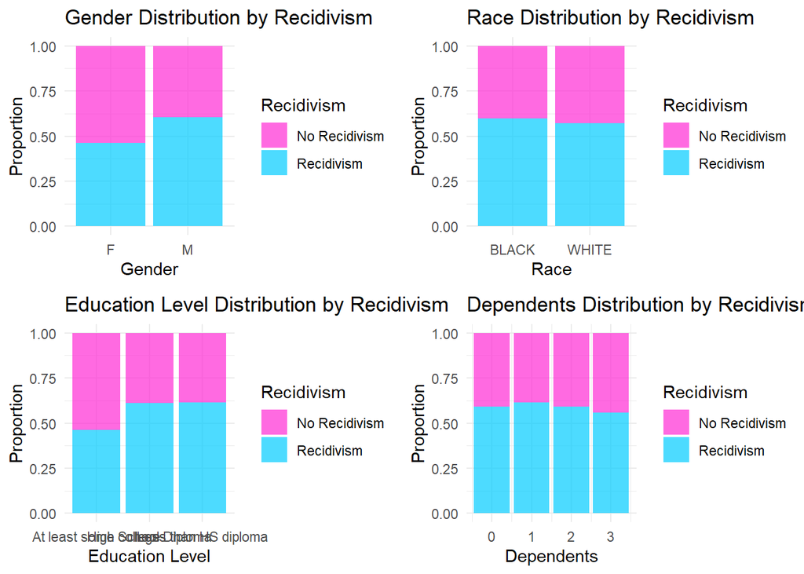

```r
# Categorical variables
# Bar plot: Gender vs. Recidivism
gender_barplot <- ggplot(df, aes(x = Gender, fill = factor(Recidivism_Within_3years))) +
  geom_bar(position = "fill", alpha = 0.7) +
  labs(title = "Gender Distribution by Recidivism",
       x = "Gender",
       y = "Proportion",
       fill = "Recidivism") +
  scale_fill_manual(values = palette_2_colors,
                    labels = c("No Recidivism", "Recidivism")) +
  theme_minimal()

# Bar plot: Race vs. Recidivism
race_barplot <- ggplot(df, aes(x = Race, fill = factor(Recidivism_Within_3years))) +
  geom_bar(position = "fill", alpha = 0.7) +
  labs(title = "Race Distribution by Recidivism",
       x = "Race",
       y = "Proportion",
       fill = "Recidivism") +
  scale_fill_manual(values = palette_2_colors,
                    labels = c("No Recidivism", "Recidivism")) +
  theme_minimal()

# Bar plot: Education Level vs. Recidivism
education_barplot <- ggplot(df, aes(x = Education_Level, fill = factor(Recidivism_Within_3years))) +
  geom_bar(position = "fill", alpha = 0.7) +
  labs(title = "Education Level Distribution by Recidivism",
       x = "Education Level",
       y = "Proportion",
       fill = "Recidivism") +
  scale_fill_manual(values = palette_2_colors,
                    labels = c("No Recidivism", "Recidivism")) +
  theme_minimal()

# Bar plot: Dependents vs. Recidivism
dependents_barplot <- ggplot(df, aes(x = Dependents, fill = factor(Recidivism_Within_3years))) +
  geom_bar(position = "fill", alpha = 0.7) +
  labs(title = "Dependents Distribution by Recidivism",
       x = "Dependents",
       y = "Proportion",
       fill = "Recidivism") +
  scale_fill_manual(values = palette_2_colors,
                    labels = c("No Recidivism", "Recidivism")) +
  theme_minimal()

# Displaying remaining bar plots
grid.arrange(gender_barplot, race_barplot, education_barplot, dependents_barplot, ncol = 2)
```